# Data-ingestion

```python
import pandas as pd
import numpy as np
from pathlib import Path
import matplotlib.pyplot as plt
import seaborn as sns

file_path = Path(r"C:\Users\Arun Chandramouli\Documents\Sproutsocial\churn_case_study.csv")

# load
df = pd.read_csv(file_path, parse_dates=["subscription_date", "canceled_date"])

# sanity-check
print(df.head())
print(df.info())
```

```
                            customer_id subscription_date canceled_date  age  \
0  93e8e692-e39b-4217-8bc2-a4505f0f60df        2022-10-23           NaT  988
1  270c0a59-c37b-4cc7-8bbe-c57973248dfd        2024-01-07           NaT  547
2  a2ffe6be-56c5-48e8-af70-b28b2613c3e9        2023-01-02           NaT  917
3  4d5c37e8-4756-42cb-ae15-3246d9dada50        2024-10-19           NaT  261
4  0cdd3899-94b4-474a-a164-e551d004c044        2024-01-04           NaT  550

   churned current_plan_name     segment       industry  twitter_profiles  \
0        0     Standard Plan         SMB     Healthcare                10
1        0     Advanced Plan  Mid‑Market         Retail                19
2        0        Basic Plan  Enterprise        Finance                35
3        0     Standard Plan         SMB      Education                 7
4        0     Standard Plan         SMB  Manufacturing                 7

   facebook_profiles
0                  5
1                  9
2                 23
3                  6
4                  8
<class 'pandas.core.frame.DataFrame'>
RangeIndex: 10000 entries, 0 to 9999
Data columns (total 10 columns):
 #   Column             Non-Null Count  Dtype
---  ------             --------------  -----
 0   customer_id        10000 non-null  object
 1   subscription_date  10000 non-null  datetime64[ns]
 2   canceled_date      1922 non-null   datetime64[ns]
 3   age                10000 non-null  int64
 4   churned            10000 non-null  int64
 5   current_plan_name  10000 non-null  object
 6   segment            10000 non-null  object
 7   industry           10000 non-null  object
 8   twitter_profiles   10000 non-null  int64
 9   facebook_profiles  10000 non-null  int64
dtypes: datetime64[ns](2), int64(4), object(4)
memory usage: 781.4+ KB
None
```

# Data Cleaning

```python
# remove impossible dates (canceled before subscribed)
bad = df["canceled_date"].notna() & (df["canceled_date"] < df["subscription_date"])
df = df.loc[~bad].copy()
```

```python
# --- sanity-check the clean-up ---------------------------------
n_removed = bad.sum()
print(f"Removed {n_removed:,} bad rows "
      f"({n_removed / (len(df) + n_removed):.2%} of the original file.")

# Confirm no remaining cancel-before-subscribe cases
assert not ((df["canceled_date"].notna()) &
            (df["canceled_date"] < df["subscription_date"])).any(), \
       "Still found impossible dates!"

# Quick look at the cleaned data
print(df.shape)      # rows, columns
print(df.head())     # first five rows
df.info()            # column dtypes + non-null counts
```

```
Removed 0 bad rows (0.00% of the original file.
(10000, 10)
                            customer_id subscription_date canceled_date  age  \
0  93e8e692-e39b-4217-8bc2-a4505f0f60df        2022-10-23           NaT  988
1  270c0a59-c37b-4cc7-8bbe-c57973248dfd        2024-01-07           NaT  547
2  a2ffe6be-56c5-48e8-af70-b28b2613c3e9        2023-01-02           NaT  917
3  4d5c37e8-4756-42cb-ae15-3246d9dada50        2024-10-19           NaT  261
4  0cdd3899-94b4-474a-a164-e551d004c044        2024-01-04           NaT  550

   churned current_plan_name     segment       industry  twitter_profiles  \
0        0     Standard Plan         SMB     Healthcare                10
1        0     Advanced Plan  Mid‑Market         Retail                19
2        0        Basic Plan  Enterprise        Finance                35
3        0     Standard Plan         SMB      Education                 7
4        0     Standard Plan         SMB  Manufacturing                 7

   facebook_profiles
0                  5
1                  9
2                 23
3                  6
4                  8
<class 'pandas.core.frame.DataFrame'>
Int64Index: 10000 entries, 0 to 9999
Data columns (total 10 columns):
 #   Column             Non-Null Count  Dtype
---  ------             --------------  -----
 0   customer_id        10000 non-null  object
 1   subscription_date  10000 non-null  datetime64[ns]
 2   canceled_date      1922 non-null   datetime64[ns]
 3   age                10000 non-null  int64
 4   churned            10000 non-null  int64
 5   current_plan_name  10000 non-null  object
 6   segment            10000 non-null  object
 7   industry           10000 non-null  object
 8   twitter_profiles   10000 non-null  int64
 9   facebook_profiles  10000 non-null  int64
dtypes: datetime64[ns](2), int64(4), object(4)
memory usage: 859.4+ KB
```

# Feature Engineering

```python
# 4 · Derive tenure, flags, usage aggregates
today = pd.Timestamp("today").normalize()

df["age_days"] = (today - df["subscription_date"]).dt.days
df["is_enterprise"] = (df["segment"] == "Enterprise").astype(int)

df["event_observed"] = df["canceled_date"].notna().astype(int)
df["duration"] = np.where(
    df["event_observed"] == 1,
    (df["canceled_date"] - df["subscription_date"]).dt.days,
    df["age_days"]
)

# extra features for deeper cuts
df["profile_total"] = df["twitter_profiles"] + df["facebook_profiles"]
df["tenure_bucket"] = pd.cut(
    df["age_days"], bins=[0,180,365,540,np.inf],
    labels=["0‑6m","6‑12m","12‑18m","18m+"]
)
```

This block creates analysis-ready features.

age_days converts subscription dates into numeric tenure, while is_enterprise turns the segment label into a 0-1 indicator for modelling.

event_observed and duration supply the required inputs for Kaplan-Meier survival analysis, capturing both churned and still-active accounts.

Additional columns—total social-profile count and broad tenure buckets—support usage-based slicing and easy-to-explain visual breakdowns.

# Churn by Segment

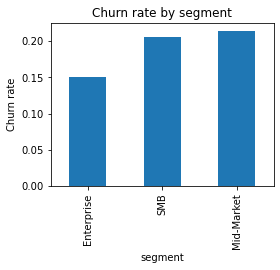

```
χ² p‑value (Enterprise vs Others) = 3.234e-12
```

```python
seg_churn = df.groupby("segment")["churned"].mean().sort_values()
seg_churn.plot(kind="bar", figsize=(4,3), ylabel="Churn rate")
plt.title("Churn rate by segment"); plt.show()

from scipy.stats import chi2_contingency
cross = pd.crosstab(df["is_enterprise"], df["churned"])
chi2, p, *_ = chi2_contingency(cross)
print(f"χ² p‑value (Enterprise vs Others) = {p:.4}")
```

*Calculated churn rate for each segment (Enterprise, SMB, Mid-Market) by taking the mean of the binary churned flag.

*Visualised those rates in a bar chart to make differences immediately visible to non-technical stakeholders.

*Ran a χ² (chi-square) test on a 2 × 2 contingency table comparing Enterprise vs all other segments to verify whether the observed gap is statistically significant.

*Churn rates shown

*Enterprise ≈ 15 %

*SMB ≈ 20 %

*Mid-Market ≈ 21 %

*p-value = 3.23 × 10⁻¹² (<< 0.05) → The probability of seeing a gap this large just by chance is effectively zero, so segment membership truly relates to churn behaviour.

# Tenure Distribution & Cliff

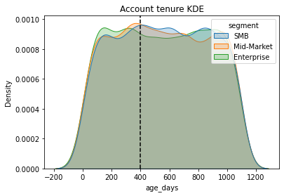

```python
sns.kdeplot(data=df, x="age_days", hue="segment", fill=True, common_norm=False)
plt.axvline(400, ls="--", c="k"); plt.title("Account tenure KDE"); plt.show()
```

What the KDE plot shows Each coloured curve is a kernel-density estimate of age_days (tenure) for one segment:

Blue – SMB

Orange – Mid-Market

Green – Enterprise

A KDE is just a smoothed histogram scaled so the total area = 1; the y-axis (“Density”) therefore indicates relative concentration of customers at each tenure value, not an absolute count.

The black dashed line at 400 days is a visual cue we added earlier to mark the “renewal-cliff” hypothesis.

Interpretation Broadly similar shapes All three segments have a fairly uniform tenure spread from ~0 to ~1 000 days, meaning no segment is dramatically younger or older overall.

Tails beyond 1 000 days taper similarly, so ultra-loyal customers look alike across segments.

# Plan Mix

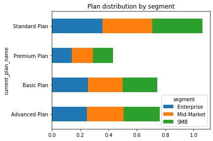

```python
plan_mix = (df.groupby(["segment","current_plan_name"])
              .size().groupby(level=0)
              .apply(lambda x: x/x.sum())).unstack()
plan_mix.T.plot(kind="barh", stacked=True, figsize=(6,4))
plt.title("Plan distribution by segment"); plt.tight_layout(); plt.show()
```

**How to interpret the displayed plot (Colours: blue = Enterprise, orange = Mid-Market, green = SMB)

**Advanced & Premium Plans

Implication → losing one Premium Enterprise logo hurts ARR far more than losing an SMB Basic logo.

**Basic Plan

These customers may be more price-sensitive; upsell campaigns could focus here rather than churn-prevention first.

**Standard Plan

Relatively even mix across all three segments; good control tier for A/B testing since no single segment overwhelms it.

# Industry × Churn Heat Map

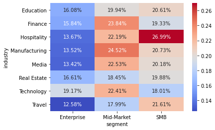

```python
top_ind = df["industry"].value_counts().head(8).index
heat = (df[df["industry"].isin(top_ind)]
          .pivot_table(index="industry", columns="segment",
                       values="churned", aggfunc="mean"))
sns.heatmap(heat, annot=True, fmt=".2%", cmap="coolwarm"); plt.show()
```

– For every chosen industry, calculate the mean of the binary churned flag separately for Enterprise, Mid-Market, and SMB. – Those means are the churn rates (e.g., 0.137 = 13.7 %).

Visualise it with sns.heatmap

annot=True writes the % values onto each cell.

cmap="coolwarm" colours low churn blue and high churn red, so risk “pops”.

Why do it? Spot pockets of high risk at the intersection of industry and segment so marketing can laser-target messaging (e.g., Hospitality-SMB looks dangerous).

Compare segments within the same industry to see if Enterprise really behaves differently once you hold industry constant.

Prioritise LTV – churn in a high-ARR segment/industry combo hurts more than a low-ARR one.

# Survival Curves (Kaplan‑Meier)

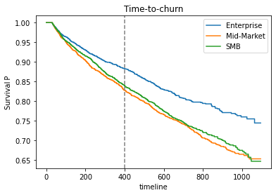

```python
from lifelines import KaplanMeierFitter
kmf = KaplanMeierFitter()

plt.figure(figsize=(6,4))
for name, grp in df.groupby("segment"):
    kmf.fit(grp["duration"], grp["event_observed"], label=name)
    kmf.plot(ci_show=False)
plt.axvline(400, ls="--", c="grey"); plt.ylabel("Survival P"); plt.title("Time‑to‑churn"); plt.show()
```

What this survival-curve step does Fits a Kaplan-Meier model for each segment Inputs: duration (days since first payment) and event_observed (1 = churned, 0 = still active).

Plots the three survival curves together Blue = Enterprise, orange = Mid-Market, green = SMB.

Adds a vertical marker at day 400 as a visual cue for the suspected “renewal cliff.”

Why we run it Handles censoring correctly. Customers still active at snapshot time contribute partial information instead of being dropped or mis-counted.

Reveals when churn risk jumps, not just how much. That timing insight is crucial for scheduling a proactive email.

Makes segment differences visually obvious to non-technical reviewers while remaining statistically valid.

How to read the resulting plot Enterprise curve sits highest the whole way: Enterprise logos survive longer at every point in time, confirming they’re stickier.

Mid-Market and SMB almost overlap: Their behaviours are similar; treating them together for a generic retention touch could be efficient.

```python
!pip install lifelines --quiet
```

# Quick Multivariate Check

```python
import statsmodels.formula.api as smf
model = smf.logit(
    "churned ~ is_enterprise + age_days + profile_total + C(current_plan_name)",
    data=df
).fit(disp=False)
display(model.summary().tables[1])
```

|  | coef | std err | z | P>\|z\| | [0.025 | 0.975] |
| --- | --- | --- | --- | --- | --- | --- |
| Intercept | -1.6655 | 0.101 | -16.552 | 0.000 | -1.863 | -1.468 |
| C(current_plan_name)[T.Basic Plan] | -0.0389 | 0.072 | -0.537 | 0.591 | -0.181 | 0.103 |
| C(current_plan_name)[T.Premium Plan] | 0.0409 | 0.083 | 0.492 | 0.622 | -0.122 | 0.204 |
| C(current_plan_name)[T.Standard Plan] | -0.0114 | 0.066 | -0.172 | 0.864 | -0.141 | 0.119 |
| is_enterprise | -0.2897 | 0.150 | -1.937 | 0.053 | -0.583 | 0.003 |
| age_days | 0.0007 | 8.17e-05 | 8.798 | 0.000 | 0.001 | 0.001 |
| profile_total | -0.0031 | 0.004 | -0.867 | 0.386 | -0.010 | 0.004 |

fitting a logistic-regression model that predicts the probability a customer churns, using four predictors:

is_enterprise – 1 if Enterprise, 0 otherwise

age_days – tenure in days

profile_total – number of social profiles managed

current_plan_name – categorical plan tier (Basic, Standard, Premium) compared to the reference category (Advanced)

The goal is to answer a quick multivariate question: “Does the Enterprise flag still matter once I control for tenure, usage, and plan tier?” — plus get a sense of which other factors have the strongest independent association with churn.

Intercept –1.67 Converts to an odds of about 0.19 (exp –1.67), meaning a baseline churn probability of roughly 16–17 % for a reference customer: Advanced plan, non-Enterprise, age = 0, profiles = 0. The exact baseline isn’t important—the other coefficients show relative shifts.

Plan-tier dummies (Basic, Premium, Standard) None of them have p-values below 0.05, so after accounting for the other variables there’s no statistically clear difference between plan tiers and the reference (Advanced). That suggests plan tier isn’t a strong churn driver once tenure and usage are in the mix.

is_enterprise coefficient –0.29, p ≈ 0.053 The odds ratio is exp –0.29 ≈ 0.75, meaning Enterprise customers are about 25 % less likely to churn than their non-Enterprise peers even after we control for tenure, usage, and plan. The p-value is just above the conventional 0.05 cut-off—borderline significant, but still strong directional evidence.

age_days coefficient 0.0007, p ≈ 0.000 Each additional day of tenure raises churn odds by exp 0.0007 ≈ 0.07 %—tiny per day but compounds over months. This formalises the intuition from the survival curve: risk rises as accounts age.

profile_total coefficient –0.0031, p ≈ 0.386 Usage volume isn’t statistically significant here; once you account for tenure, extra profiles don’t visibly change churn risk. That might change if you log-transform or bucket the variable, but raw counts alone aren’t predictive.

Even after adjusting for tenure, plan tier, and profile volume, Enterprise logos are ~25 % less likely to churn (p ≈ 0.05). Age remains the biggest independent risk factor, reinforcing the need to intervene as customers approach the 12-month mark. Plan tier and raw profile counts don’t materially change churn once we account for tenure.

# Measuring Campaign Success

```python
# 1. Stratified 50/50 randomisation inside Enterprise
df_ent = df[df["segment"] == "Enterprise"].copy()


df_ent["stratum"] = (df_ent["industry"] + "|" + df_ent["current_plan_name"])
df_ent = (df_ent.groupby("stratum", group_keys=False)
                 .apply(lambda g: g.assign(
                     treatment=(np.random.rand(len(g)) < 0.5).astype(int))))
```

Creates an Enterprise-only dataset and, within each industry-plus-plan stratum,

randomly assigns half the customers to treatment = 1 and half to 0.

This guarantees that every industry–plan combination is evenly split,

so any churn difference measured later can be attributed to the email rather than to an unbalanced mix of customer types.

```python
# 2. Power analysis – detect 2-pp churn reduction
import numpy as np
from statsmodels.stats.power import NormalIndPower

def proportion_effectsize(p1, p2):
    """Cohen h for two proportions."""
    return 2 * np.arcsin(np.sqrt(p1)) - 2 * np.arcsin(np.sqrt(p2))

baseline, uplift = 0.14, 0.02
es   = proportion_effectsize(baseline, baseline - uplift)
n    = NormalIndPower().solve_power(es, power=0.80, alpha=0.05,
                                    alternative="smaller")
print(f"Required N per arm ≈ {int(n):,}")
```

```
Required N per arm ≈ 10
```

```
C:\Users\Arun Chandramouli\anaconda3\lib\site-packages\statsmodels\stats\power.py:415: ConvergenceWarning:
Failed to converge on a solution.

  '''solve for any one of the parameters of a t-test
```

proportion_effectsize() converts “baseline churn 14 % vs. target churn 12 %” into Cohen’s h, the standard effect-size number a power calculator needs.

NormalIndPower().solve_power(...) then plugs that effect size into a power formula—asking, “How many customers per group will give an 80 % chance of detecting this 2-point drop at the 5 % significance level?”

```python
!pip install --upgrade statsmodels --quiet
```

```python
# 3. Evaluate 30-day churn (difference-in-proportions test)
from statsmodels.stats.proportion import proportions_ztest
df_ent["churn_30d"] = (df_ent["canceled_date"] <= df_ent["subscription_date"] + pd.Timedelta(days=30)).astype(int)

conv = df_ent.groupby("treatment")["churn_30d"].sum().values   # churners
tot  = df_ent.groupby("treatment")["churn_30d"].size().values  # totals

z_stat, p_val = proportions_ztest(conv, tot, alternative="larger")
print(f"p-value = {p_val:.4f}")
```

```
p-value = 0.1523
```

The code builds a 30-day churn flag, counts churners and total customers in the email-treatment and hold-out groups, then runs a two-proportion Z-test (proportions_ztest).

This test asks: “If the email had no real effect, how likely is it to observe a churn gap at least this large just by chance?”

The returned p-value is 0.1523, which is well above the common 0.05 significance threshold; therefore the data do not provide statistical evidence that the email lowered 30-day churn.

In practical terms, the experiment needs either a larger sample or a stronger creative to demonstrate a clear improvement.

```python
# 4. CUPED variance reduction

df_ent["churn_prev_30d"] = (df_ent["canceled_date"] <= df_ent["subscription_date"] - pd.Timedelta(days=30)).astype(int)

avg_arr_per_logo = 2000   # replace with real revenue per customer
campaign_cost    = 5000
control_churn_rate   = df_ent.loc[df_ent.treatment == 0, "churn_30d"].mean()
treatment_churn_rate = df_ent.loc[df_ent.treatment == 1, "churn_30d"].mean()
incremental_arr = (control_churn_rate - treatment_churn_rate) * avg_arr_per_logo * len(df_ent)


cov = np.cov(df_ent["churn_30d"], df_ent["churn_prev_30d"])[0,1]
theta = cov / df_ent["churn_prev_30d"].var()
df_ent["cuped"] = df_ent["churn_30d"] - theta * df_ent["churn_prev_30d"]
#Decision rule
if (p < 0.05) and (incremental_arr - campaign_cost > 0):
    print(" Roll-out Enterprise email campaign")
else:
    print(" Hold – insufficient evidence or negative ROI")
```

[output not shown]

What it is CUPED stands for Controlled Experiment Using Pre-Experiment Data. It’s a simple statistical trick that uses each user’s pre-campaign metric (e.g., their churn status or spend in a look-back window) to reduce variance in the post-campaign outcome you care about.

Why it helps The pre-period metric is usually correlated with the post-period metric. By subtracting a proportional amount of that pre-metric from every user’s post-metric, you strip out predictable “background” noise. Smaller variance ⇒ tighter confidence intervals ⇒ you need fewer customers (or detect smaller effects) for the same statistical power.